- Back to index

# Subsetting & merging the dataset for analysis

This document describes data on those three events we are interested in, which are

1. exit to labour market
2. entry to maternity
3. entry to pension

Tasks performed:

1. merging the original register and data files both at the household and personal level from year 2008, 2009, 2010 and 2011 (each containing data from that year and three years before)
2. subsetting same variables from each datasets
   - same set of variables from personal08, personal09 and personal10 datas
   - same set of variables from household08, household09 and household10 datas
3. combining the datasets with identical variables
   - one dataset including all the cases from personal files (~4 million cases)
   - another dataset including all the cases from household files (~2 million cases)
4. subsetting only cases with unique `year-cntry-id` -combination (longitudinal data files are overlapping)
5. merging the needed household level variables with personal data
6. manipulating the dataset so that the year of exit/entry is found plus the required information from years before and after the event

# Data and rationale behind coding exits and entries

Main source of information on the events are variables PL030 (*Self-defined current economic status*) and RB110 (*Membership status*). The values are explained in the tables below.

## Exit to labour market & entry to pension system

As for **exit to labour market** and for **enter to pension system** the information from PL030/Pl031 is used. As those variables are complementary (individuals have value in either of variable (missing data still substantial problem!!) a synthetic variable `econStatus` is created so **that value from PL031 is taken first, and if it is missing, the value from PL030 is taken and simultaneuosly recoded to match PL031 coding**. The results is a variable with values as in the table below.

Table: values and labels in variable PL031

| Value | Label |
| --- | --- |
| 1 | Employee working full-time |
| 2 | Employee working part-time |
| 3 | Self-employed working full-time (including family worker) |
| 4 | Self-employed working part-time (including family worker) |
| 5 | Unemployed |
| 6 | Pupil, student, further training, unpaid work experience |
| 7 | In retirement or in early retirement or has given up business |
| 8 | Permanently disabled or/and unfit to work |
| 9 | In compulsory military community or service |
| 10 | Fulfilling domestic tasks and care responsibilities |
| 11 | Other inactive person |

**To put it briefly,**

- **Exit** to labour market is coded as change from `econStatus == 6` to `econStatus == 1:4`.
- **Entry** to pension system is coded as change from `econStatus != 7` to `econStatus == 7`.

## Entry to motherhood

Here the solution is to extract new babies based on variable RB110 (*Membership status*) (See the values in table below). Individual with value `4` are new babies. Babies are linked with their mothers using variable RB230 (*Mother ID*). The year the baby has appeared is the year **birth event** has taken place.

Table: values and labels in variable

[output not shown]

## Summarising the data analysis

- all the analysis is programmed in reproducible manner from the original data
  - all the changes in coding made for the code are inherited for later analysis
  - variables of interest can be added easily
  - odds findings can be easily tracked to programming errors
- countrycode for Greece is harmonised as **EL** for all data
- from most of the countries the panel components is **four years**, except France, Luxembourg, Norway have six years panel. (See: [Melissa Engel and Sandra Schaffner (2012) How to Use the EU-SILC Panel to Analyse Monthly and Hourly Wages](http://www.rwi-essen.de/media/content/pages/publikationen/ruhr-economic-papers/REP_12_390.pdf))
- missing data is a major problem..

# Descriptive graphics

The following plots are provided from all the events

1. histogram: Number of events by year & country
2. boxplot: Distribution of age of individuals by year & country
3. boxplot: Distribution of age of individuals by country
4. boxplot: Distribution of absolute employee cash income (gross) before and after the event
5. lineplot: Change in absolute employee cash income (gross) due to event (years before and after)

## Exit to labour market

### Number of events by year & country

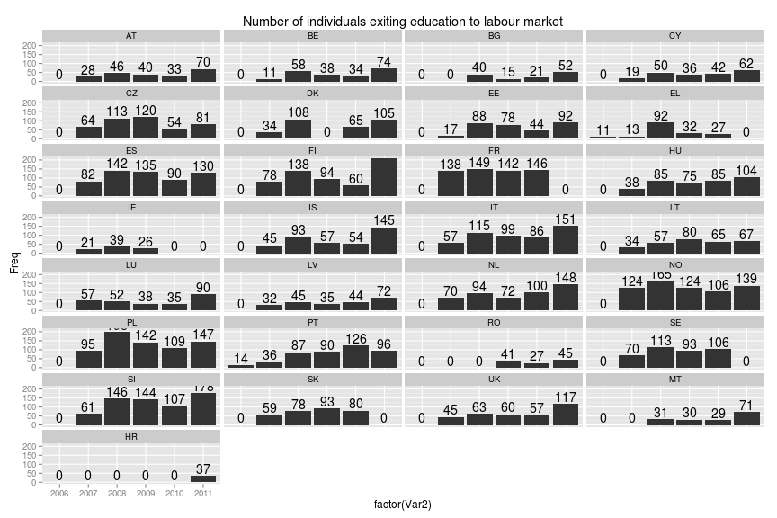

### Distribution of age of individuals by year & country

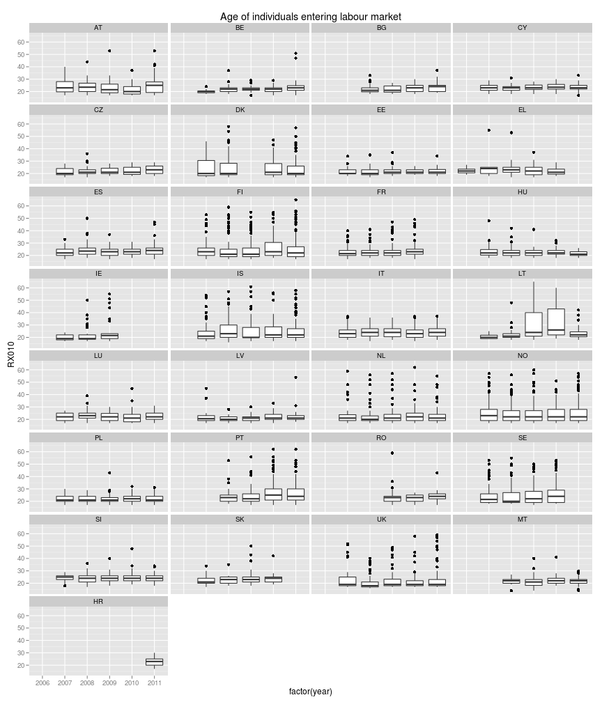

### Distribution of age of individuals by country

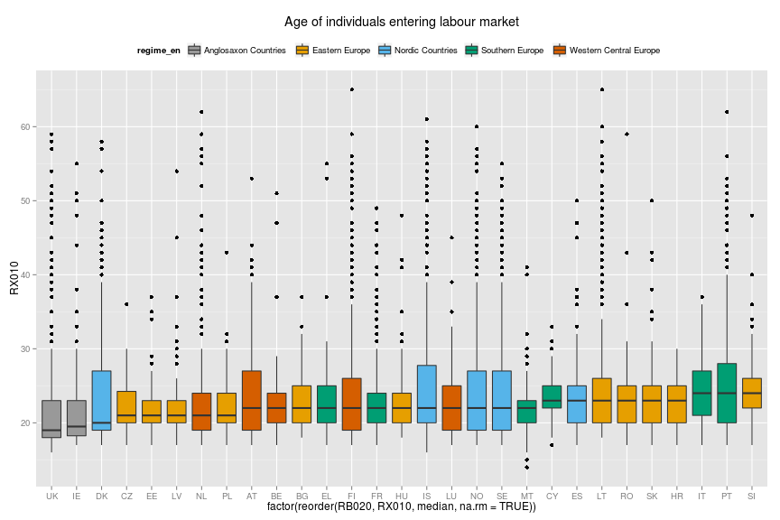

### Distribution of absolute employee cash income (gross) before and after the event

**NOTE**

- on the x-axis 0 means the first year in employment. -1 is the last year as student and 1 is the 1st year after event, eg. 2nd year of employment

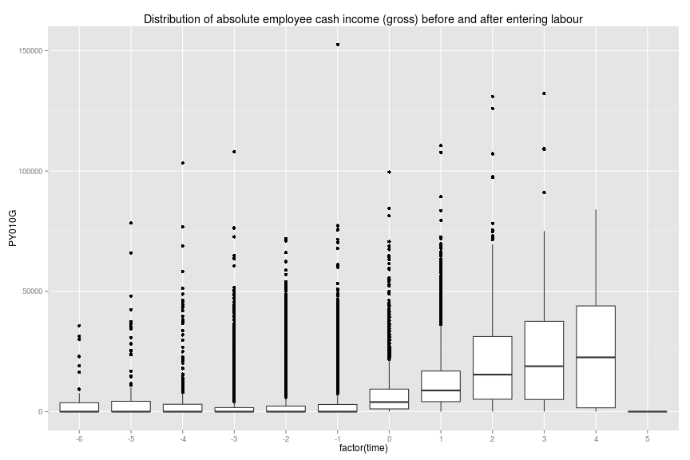

### Change in absolute employee cash income (gross) due to event (years before and after)

*Line is at the first year of employment*!

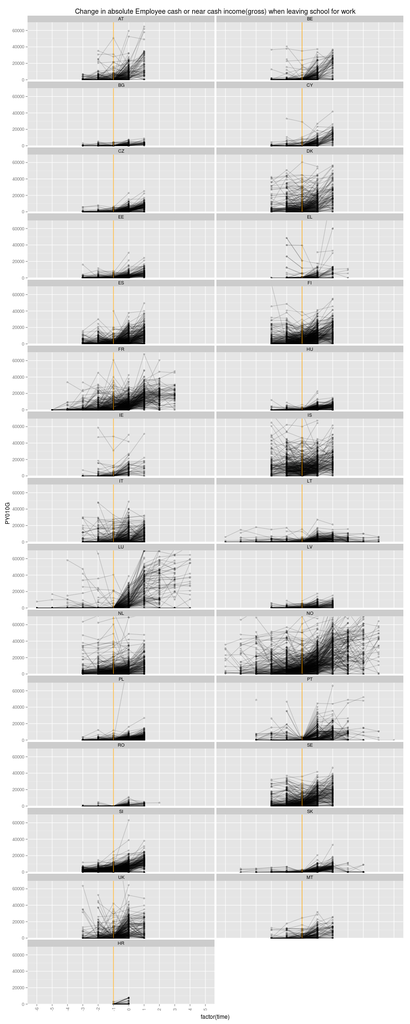

### Notes on exiting education to labour market

- plots do make sense
  - coding is probably done somewhat correctly

## Entry to maternity

Making sense of the newly born babies and their mothers

- some given birth in 2005, those have to be excluded as there are no information from year before
- only cases that have infomation minimum -1, 0 and +1 year are included

### Number of events by year & country

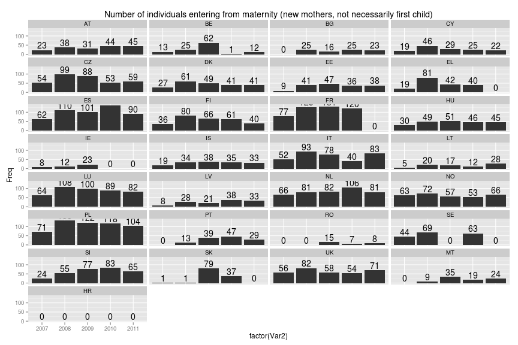

### Distribution of age of individuals by year & country

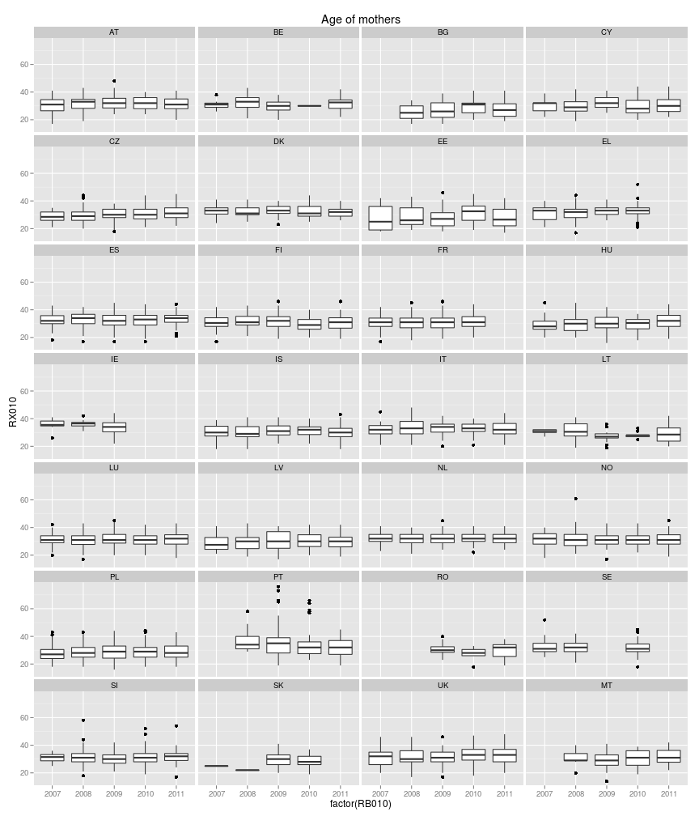

### Distribution of age of individuals by country

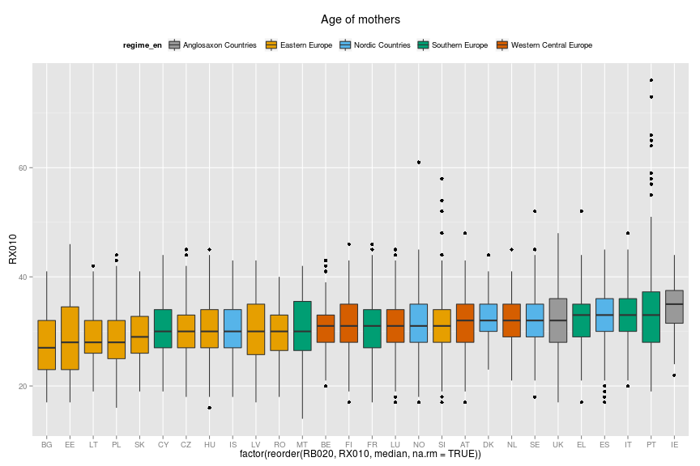

### Distribution of absolute employee cash income (gross) before and after the event

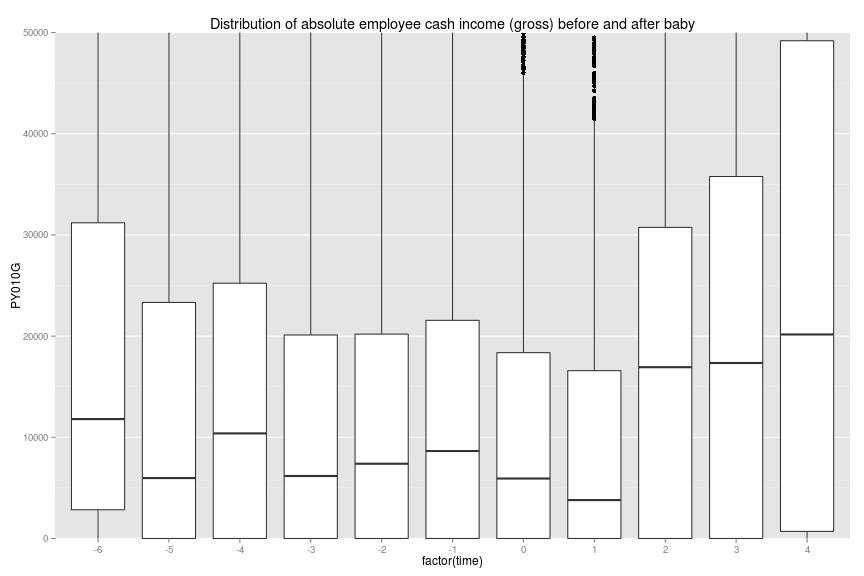

### Change in absolute employee cash income (gross) due to event (years before and after)

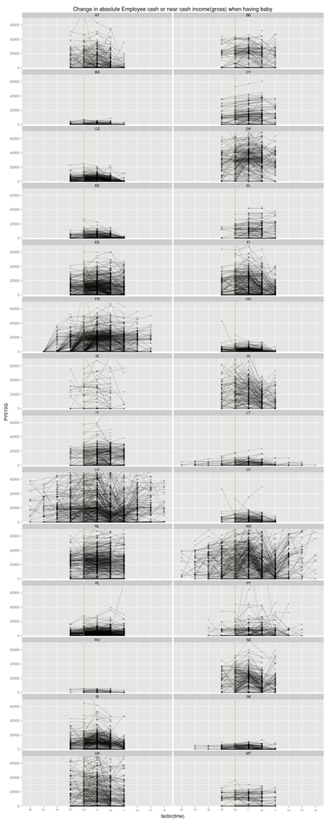

## Entry to pension

### Number of events by year & country

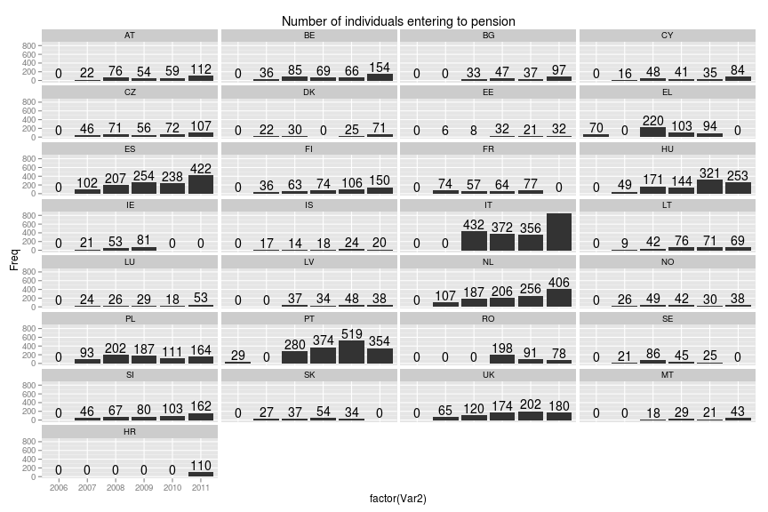

### Distribution of age of individuals by year & country

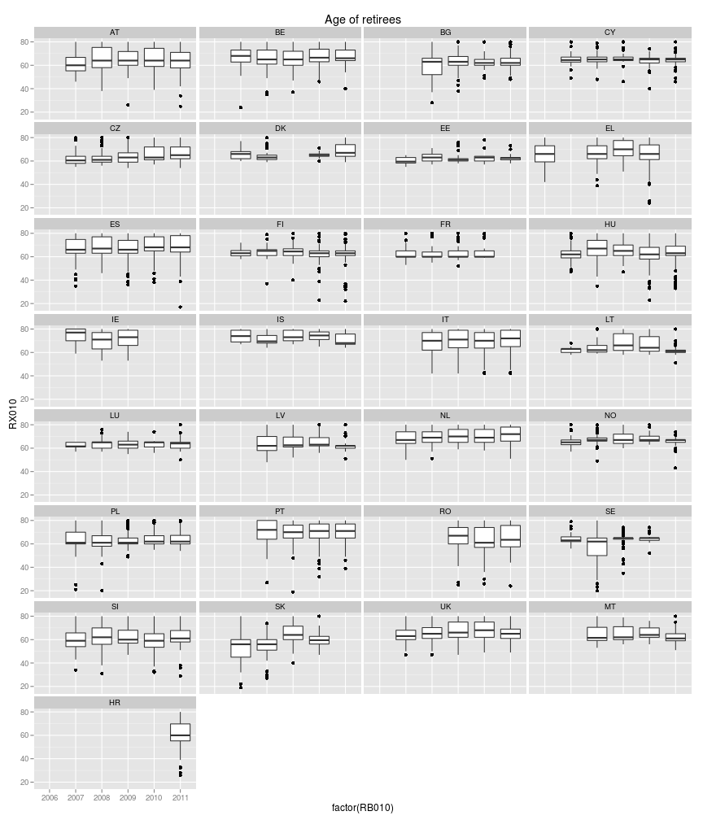

### Distribution of age of individuals by country

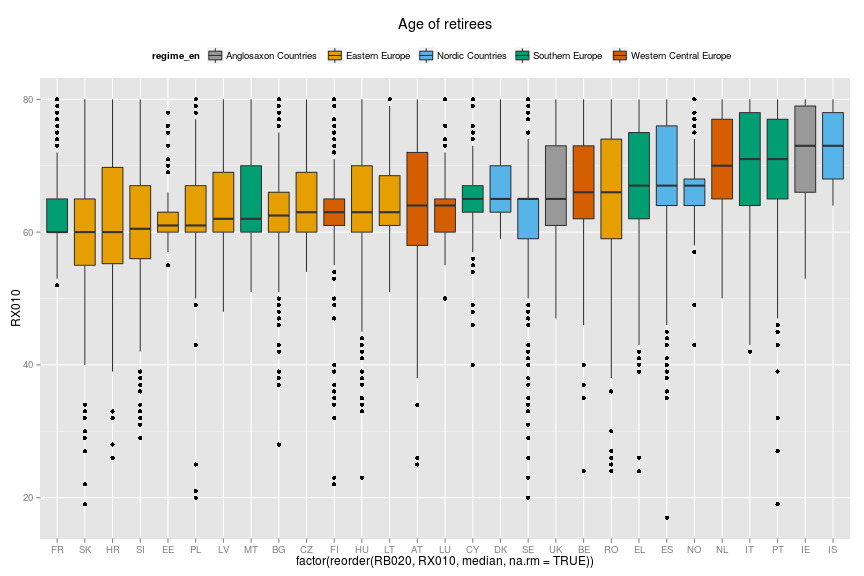

### Distribution of absolute employee cash income (gross) before and after the event

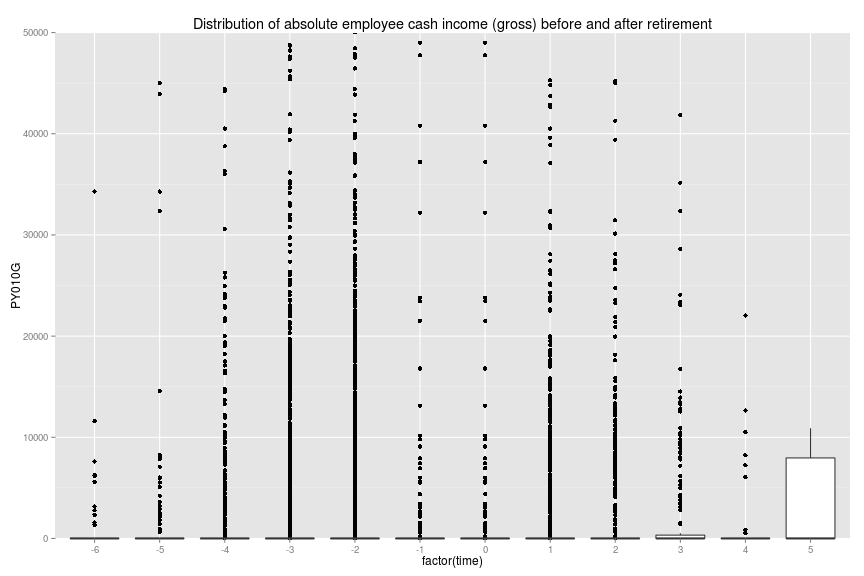

### Change in absolute employee cash income (gross) due to event (years before and after)

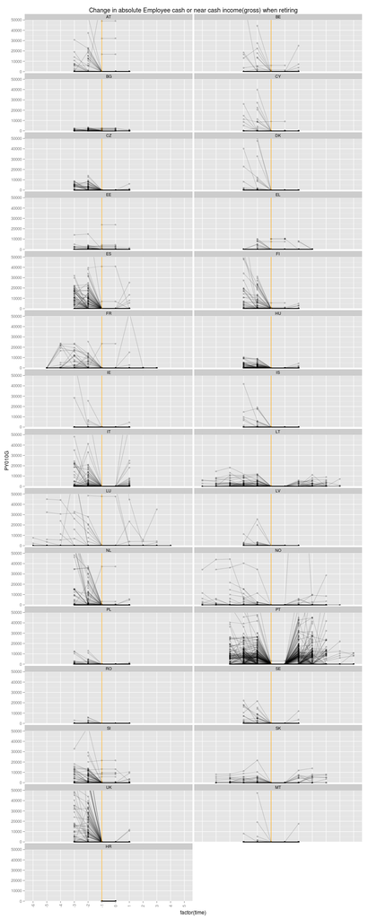

# Misc text and tables

Following variables are selected:

From **personal register**

| varname | label |
| --- | --- |
| PER_ID | unique year, cntry, personal ID |
| RB010 | year |
| RB020 | cntry |
| RB030 | Personal ID |
| RB040 | Current Household ID |
| RB060 | Personal base weight |
| RB080 | Year of birth |
| RB090 | Sex |
| RB110 | Membership status |
| RB210 | Basic activity status |
| RB230 | Mother ID |
| RX010 | Age at the date of the interview |
| RX020 | Age at the end of the income reference period |

From **personal data**

| varname | label |
| --- | --- |
| PB190 | Marital status |
| PB200 | Consensual union |
| PL030 | Self-defined current economic status |
| PL040 | Status in employment |
| PY010G | Employee cash or near cash income(gross) |

From **household data**

| varname | label |
| --- | --- |
| HB010 | Year of the survey |
| HB020 | Country |
| HB030 | Household id |
| DB110 | Household status |
| HY020 | total disposable household income |
| HX050 | Equivivalized household size |
| HX090 | Equivivalized household income |